# Practical Machine Learning Project Course

Sivuyile Nzimeni

15/09/2020

# Introduction

Since our dataset contains 160 exploratory variables. Feature Selection will be necessary. To gain a better understanding of the data, we visit the [data source](http://web.archive.org/web/20161224072740/http:/groupware.les.inf.puc-rio.br/har) which contains the data dictionary. Exploring the variable definitions provides insights about the purpose of certain variables.

Our primary objective is to use data from the **accelerometers**,**belt**,**forearm**,**arm**, and **dumbell** of 6 participants. Ultimately, we will use the data to identify the exercise (“classe”) among the participants.

## Preprocessing

The exploratory analysis reveals that the data contains a mixture of device-level data and engineered features(such as,Kurtosis,Skewness etc.).Including these derived features introduces a several hurdles. For example, some of the engineered features introduce missing values. In the pre-processing phase, we remove all derived features reducing the feature from 160 variables to 55.

In addition, all numeric variables were scaled and centred. Lastly, Yeo-Johnson transformation were utilised. These preprocessing procedures were applied to both the test and the training test. Given the fact that the task at hand is a classification problem, we selected random forest and knn classification.

# RandomForest

First, we use the `ranger` package to set up Random Forest on the training dataset.

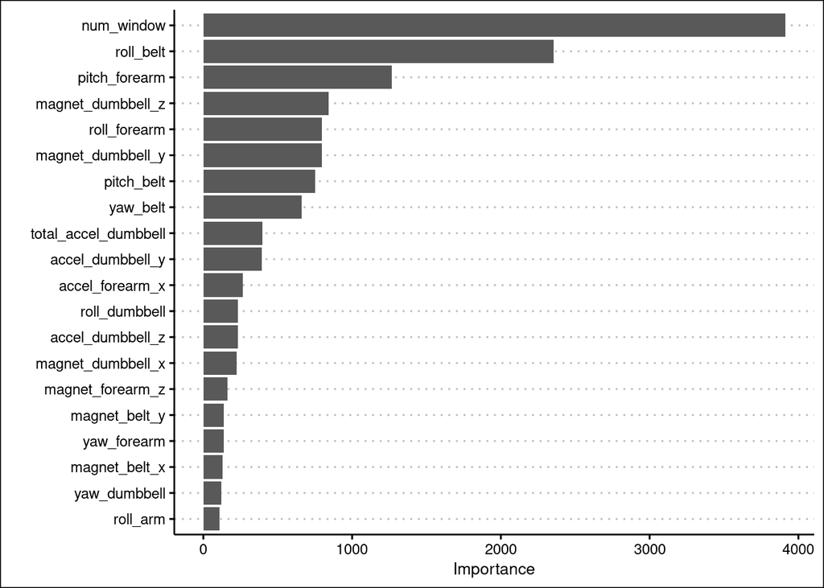

In summary, the random forest model had accuracy of 0.997. The plot above indicates the top 20 variables extracted from the random forest.

# KNN Approach

A second approach was to the use of K-Nearest Neighbour model to classify the classe outcomes in the training dataset. The parameters of the KNN model included a `tuneGrid` of k 1 to 20. In addition, the training dataset was cross-validated. Similarly to the random forest, the primary measure was accuracy.

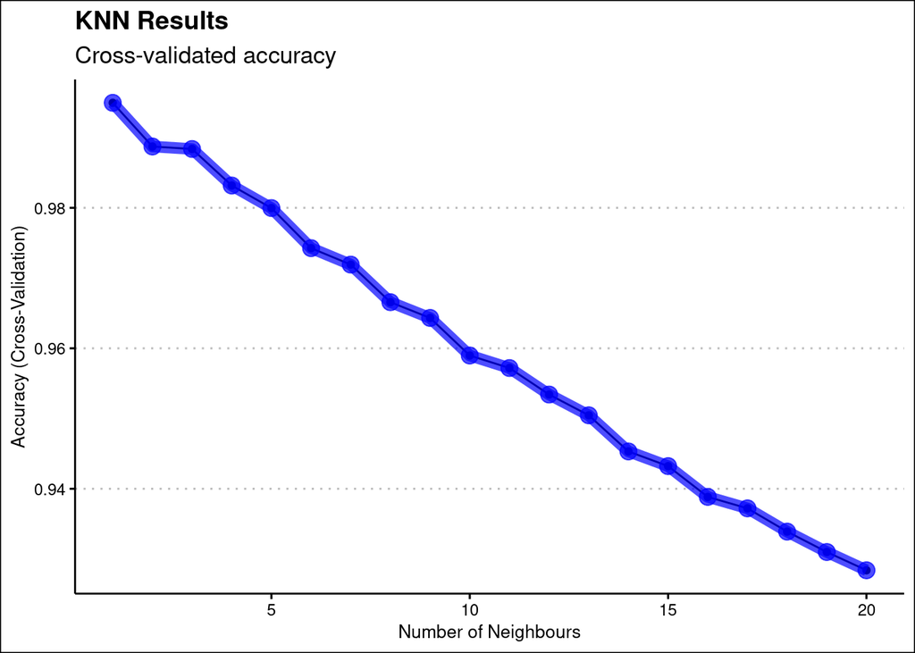

The results of the KNN model indicate 1 Neighbour as yielding the highest accuracy value(0.995). As the number of neighbours increases, the accuracy decreases.

# CONCLUSION

Using Random Forest and KNN models in the `caret` package, we were able to correctly classify the classe type with 0.997 and 0.995 accuracy, respectively.